# Clustering

2022-12-12

## Clustering

- The algorithms we have described up to now are examples of a general approach referred to as *supervised* machine learning.
- The name comes from the fact that we use the outcomes in a training set to *supervise* the creation of our prediction algorithm.
- There is another subset of machine learning referred to as *unsupervised*.
- In this subset we do not necessarily know the outcomes and instead are interested in discovering groups.

## Clustering

- These algorithms are also referred to as *clustering* algorithms since predictors are used to define *clusters*.
- In the two examples we have shown here, clustering would not be very useful.
- In the first example, if we are simply given the heights we will not be able to discover two groups, males and females, because the intersection is large.

## Clustering

- In the second example, we can see from plotting the predictors that discovering the two digits, two and seven, will be challenging:

```r
library(tidyverse)
library(dslabs)
data("mnist_27")
mnist_27$train |> qplot(x_1, x_2, data = _)
```

## Clustering

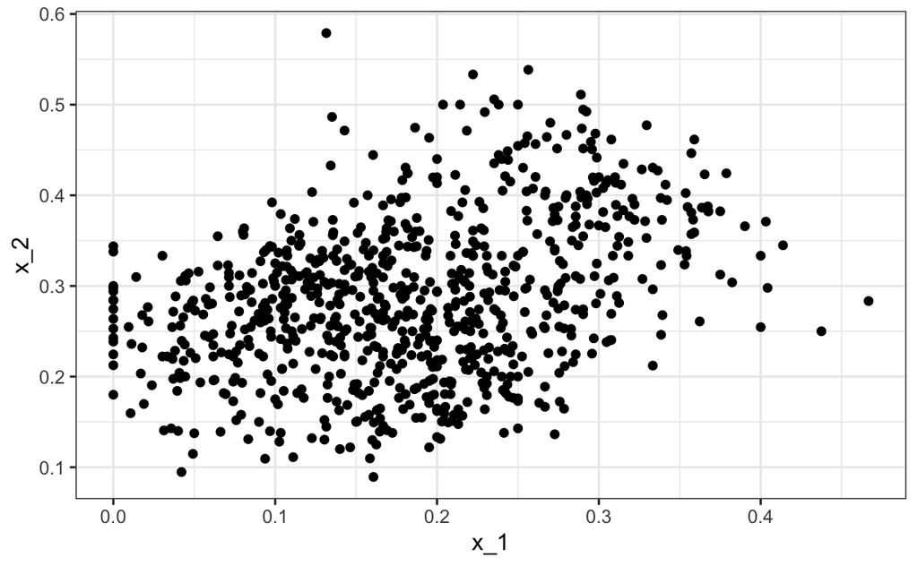

## Clustering

- However, there are applications in which unsupervised learning can be a powerful technique, in particular as an exploratory tool.
- A first step in any clustering algorithm is defining a distance between observations or groups of observations.
- Then we need to decide how to join observations into clusters.
- There are many algorithms for doing this.

## Clustering

- Here we introduce two as examples: hierarchical and k-means.
- We will construct a simple example based on movie ratings.
- Here we quickly construct a matrix `x` that has ratings for the 50 movies with the most ratings.

## Clustering

```r
data("movielens")
top <- movielens |>
  group_by(movieId) |>
  summarize(n=n(), title = first(title)) |>
  top_n(50, n) |>
  pull(movieId)
x <- movielens |>
  filter(movieId %in% top) |>
  group_by(userId) |>
  filter(n() >= 25) |>
  ungroup() |>
  select(title, userId, rating) |>
  spread(userId, rating)
row_names <- str_remove(x$title, ": Episode") |> str_trunc(20)
x <- x[,-1] |> as.matrix()
x <- sweep(x, 2, colMeans(x, na.rm = TRUE))
x <- sweep(x, 1, rowMeans(x, na.rm = TRUE))
rownames(x) <- row_names
```

## Clustering

- We want to use these data to find out if there are clusters of movies based on the ratings from 139 movie raters.
- A first step is to find the distance between each pair of movies using the `dist` function:

```r
d <- dist(x)
```

## Hierarchical clustering

- With the distance between each pair of movies computed, we need an algorithm to define groups from these.
- Hierarchical clustering starts by defining each observation as a separate group, then the two closest groups are joined into a group iteratively until there is just one group including all the observations.
- The `hclust` function implements this algorithm and it takes a distance as input.

```r
h <- hclust(d)
```

- We can see the resulting groups using a *dendrogram*.

## Hierarchical clustering

```r
plot(h, cex = 0.65, main = "", xlab = "")
```

## Hierarchical clustering

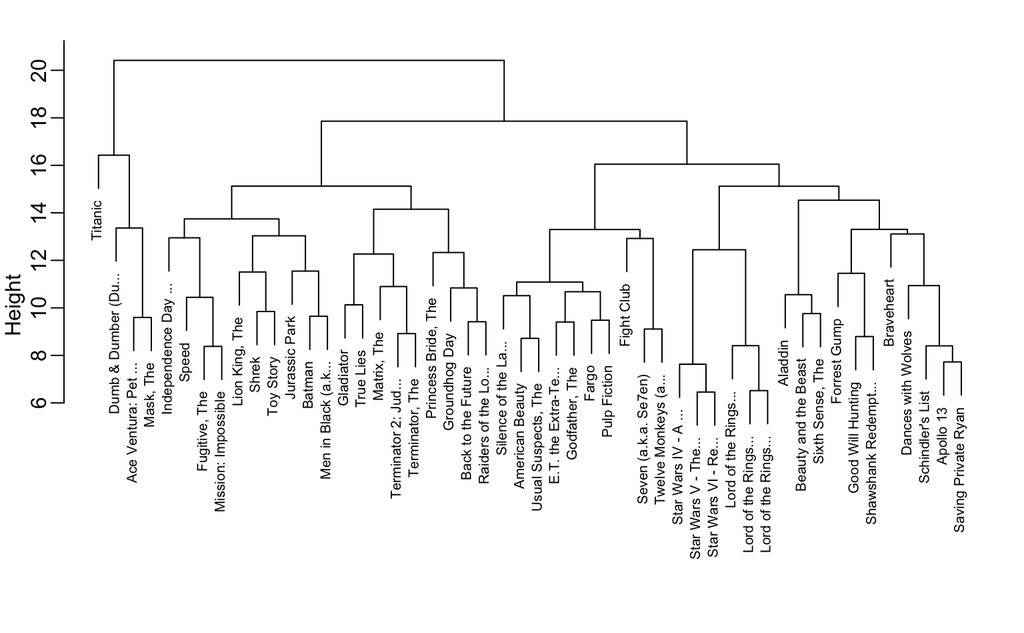

## Hierarchical clustering

- This graph gives us an approximation between the distance between any two movies.
- To find this distance we find the first location, from top to bottom, where these movies split into two different groups.
- The height of this location is the distance between these two groups.
- So, for example, the distance between the three *Star Wars* movies is 8 or less, while the distance between *Raiders of the Lost of Ark* and *Silence of the Lambs* is about 17.

## Hierarchical clustering

- To generate actual groups we can do one of two things: 1) decide on a minimum distance needed for observations to be in the same group or 2) decide on the number of groups you want and then find the minimum distance that achieves this.
- The function `cutree` can be applied to the output of `hclust` to perform either of these two operations and generate groups.

```r
groups <- cutree(h, k = 10)
```

## Hierarchical clustering

- Note that the clustering provides some insights into types of movies.
- Group 4 appears to be award winning and popular movies:

```r
names(groups)[groups==4]
```

```
#> [1] "Apollo 13"            "Braveheart"           "Dances with Wolves"
#> [4] "Forrest Gump"         "Good Will Hunting"    "Saving Private Ryan"
#> [7] "Schindler's List"     "Shawshank Redempt..."
```

## Hierarchical clustering

- And group 9 appears to be nerd movies:

```r
names(groups)[groups==9]
```

```
#> [1] "Lord of the Rings..." "Lord of the Rings..." "Lord of the Rings..."
#> [4] "Star Wars IV - A ..." "Star Wars V - The..." "Star Wars VI - Re..."
```

## Hierarchical clustering

- We can change the size of the group by either making `k` larger or `h` smaller.
- We can also explore the data to see if there are clusters of movie raters.

## Hierarchical clustering

```r
h_2 <- dist(t(x)) |> hclust()
```

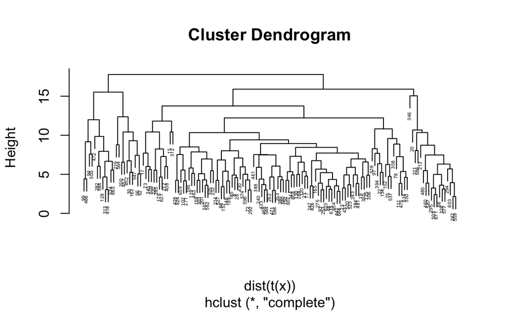

```r
plot(h_2, cex = 0.35)
```

## k-means

- To use the k-means clustering algorithm we have to pre-define \(k\), the number of clusters we want to define.
- The k-means algorithm is iterative.
- The first step is to define \(k\) centers.
- Then each observation is assigned to the cluster with the closest center to that observation.
- In a second step the centers are redefined using the observation in each cluster: the column means are used to define a *centroid*.

## k-means

- We repeat these two steps until the centers converge.
- The `kmeans` function included in R-base does not handle NAs.
- For illustrative purposes we will fill out the NAs with 0s.
- In general, the choice of how to fill in missing data, or if one should do it at all, should be made with care.

```r
x_0 <- x
x_0[is.na(x_0)] <- 0
k <- kmeans(x_0, centers = 10)
```

## k-means

- The cluster assignments are in the `cluster` component:

```r
groups <- k$cluster
```

- Note that because the first center is chosen at random, the final clusters are random.
- We impose some stability by repeating the entire function several times and averaging the results.
- The number of random starting values to use can be assigned through the `nstart` argument.

```r
k <- kmeans(x_0, centers = 10, nstart = 25)
```

## Heatmaps

- The first step is compute:

```r
data("tissue_gene_expression")
x <- sweep(tissue_gene_expression$x, 2, colMeans(tissue_gene_expression$x))
h_1 <- hclust(dist(x))
h_2 <- hclust(dist(t(x)))
```

- Now we can use the results of this clustering to order the rows and columns.

```r
image(x[h_1$order, h_2$order])
```

## Heatmaps

- But there is `heatmap` function that does it for us:

```r
heatmap(x, col = RColorBrewer::brewer.pal(11, "Spectral"))
```

- We do not show the results of the heatmap function because there are too many features for the plot to be useful.
- We will therefore filter some columns and remake the plots.

## Filtering features

- If the information about clusters is included in just a few features, including all the features can add enough noise that detecting clusters becomes challenging.
- One simple approach to try to remove features with no information is to only include those with high variance.
- In the movie example, a user with low variance in their ratings is not really informative: all the movies seem about the same to them.

## Filtering features

- Here is an example of how we can include only the features with high variance.

```
library(matrixStats)
sds <- colSds(x, na.rm = TRUE)
o <- order(sds, decreasing = TRUE)[1:25]
```

## Filtering features

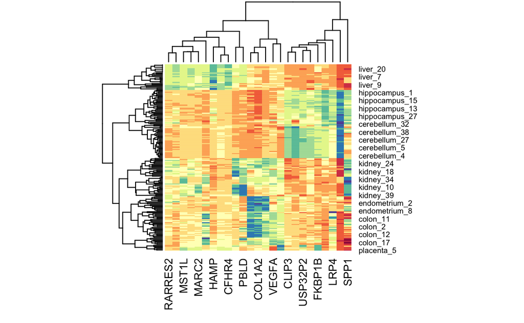

```r
heatmap(x[,o], col = RColorBrewer::brewer.pal(11, "Spectral"))
```